# Group by community type, then test the genes: does community explain more than the method? (Study B, Question 3)

> **What this document is.** The third Study B question: if we group people by **community type** (Lactobacillus-dominant vs anaerobe) and test their genes, does community type explain host gene expression better than the contraceptive method does? The community label is defined **from the species table** and tested **on the gene table** — never define a group from the table you then test it on. Question 2 (ring vs systemic) lives in `02-ring-vs-systemic.html` and `03-three-arms-review.html`; full QC lives in `01-qc.html`.

```r
library(tidyverse)
library(here)
library(DESeq2)
library(microViz)
library(phyloseq)
library(vegan)
library(patchwork)   # lets p_com + p_arm put two plots side by side
library(ggrepel)

source(here("R/count_tables.R"))

d  <- read_counts("group_b")
sp <- d$species         # 220 species  x 93 samples, RAW counts
ge <- d$genes           # 14,226 genes x 93 samples, RAW counts
md <- d$metadata        # one row per sample, same order as the columns

md <- md |>
  mutate(arm_group = if_else(arm == "ring", "ring", "systemic"))

# Community type: Lactobacillus genus >= half of the species reads.
# Defined from the SPECIES table only.
lacto_taxa <- d$taxonomy |> filter(Genus == "Lactobacillus") |> pull(taxon)
lacto_frac <- colSums(sp[lacto_taxa, , drop = FALSE]) / colSums(sp)
md$community <- ifelse(lacto_frac >= 0.5, "lactobacillus", "anaerobe")
```

# 1. QC for this analysis

```r
stopifnot(identical(colnames(ge), md$sample_id))   # order check: DESeq2 would
                                                   # fail silently otherwise
n_comm <- table(md$community)
knitr::kable(table(Arm = md$arm, Community = md$community),
             caption = "Community type by arm")
```

Community type by arm

|  | anaerobe | lactobacillus |
| --- | --- | --- |
| injectable | 20 | 19 |
| pill | 11 | 17 |
| ring | 14 | 12 |

- **Order check passed** for the gene table.
- **Community split:** 48 lactobacillus-dominant vs 45 anaerobe samples — comfortably balanced for testing.
- **Community is not a proxy for method:** the two groupings are independent (chi-squared p = 0.5), so this is a fair head-to-head, not a confounded one.
- **Carried flags from `01-qc.html`:** `B093` carries heavy blood signal (HBB/HBA, about a third of its reads); vaginal pH differs by arm (p = 0.02) — and, as section 5 shows, far more strongly by community type, which matters for reading the method comparison.

# 2. The gene map, coloured by community type

Same gene ordination as Question 2 — genes with ≥ 10 reads in ≥ 10 samples, CLR transform, Euclidean PCoA — now coloured by community type instead of arm.

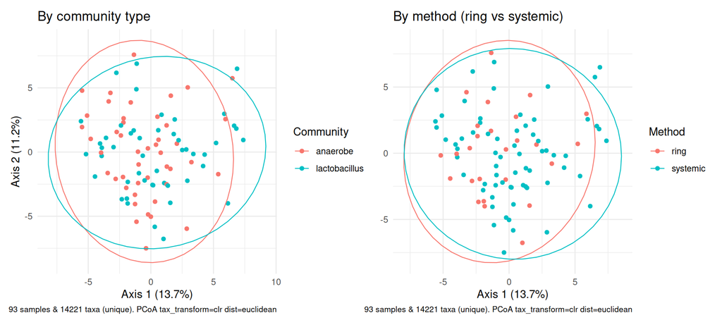

Gene-table PCoA (CLR + Euclidean). Left: coloured by community type. Right: coloured by ring vs systemic for comparison.

```r
ps <- as_counts(dataset = "group_b", table = "rnaseq",
                min_count = 10, min_samples = 10, data = d)
sd <- as(sample_data(ps), "data.frame")
idx <- match(sd$sample_id, md$sample_id)
sd$arm_group <- md$arm_group[idx]
sd$community <- md$community[idx]
sample_data(ps) <- sample_data(sd)

ord <- ps |>
  tax_transform("clr", zero_replace = "halfmin") |>
  dist_calc("euclidean") |>
  ord_calc("PCoA")

eig <- attr(ord, "ord")$CA$eig
sh  <- round(100 * eig / sum(eig), 1)

p_com <- ord_plot(ord, axes = 1:2, color = "community") +
  stat_ellipse(aes(colour = community), type = "norm", linewidth = 0.4) +
  labs(title = "By community type", x = sprintf("Axis 1 (%s%%)", sh[1]),
       y = sprintf("Axis 2 (%s%%)", sh[2]), colour = "Community")
p_arm <- ord_plot(ord, axes = 1:2, color = "arm_group") +
  stat_ellipse(aes(colour = arm_group), type = "norm", linewidth = 0.4) +
  labs(title = "By method (ring vs systemic)", x = sprintf("Axis 1 (%s%%)", sh[1]),
       y = NULL, colour = "Method")
p_com + p_arm
```

# 3. PERMANOVA: community vs method, head to head

Both groupings go into **one** model with `by = "margin"`, so each gets its own test adjusted for the other ([Anderson 2001](https://doi.org/10.1111/j.1442-9993.2001.01070.pp.x)) — that is the fair comparison the slides quote.

```r
dm <- attr(ord, "dist")
meta_p <- data.frame(sample_data(ps))[rownames(as.matrix(dm)), ]
meta_p$arm_group <- factor(meta_p$arm_group, levels = c("systemic", "ring"))
set.seed(1)
both    <- adonis2(dm ~ community + arm_group, data = meta_p,
                   permutations = 9999, by = "margin")
com_only <- adonis2(dm ~ community, data = meta_p, permutations = 9999)
arm_only <- adonis2(dm ~ arm_group, data = meta_p, permutations = 9999)
disp <- permutest(betadisper(dm, meta_p$community), permutations = 9999)

q3_com_r2 <- round(100 * both$R2[1], 1)   # row 1 = community (margin test)
q3_com_p  <- round(both$`Pr(>F)`[1], 4)
q3_arm_r2 <- round(100 * both$R2[2], 1)   # row 2 = method
q3_arm_p  <- round(both$`Pr(>F)`[2], 4)
q3_disp_p <- round(disp$tab$`Pr(>F)`[1], 2)
```

```r
knitr::kable(
  tibble(
    model = c("both groupings, adjusted for each other", "",
              "each grouping alone", "", ""),
    term  = c("community type", "method (ring vs systemic)",
              "community type", "method (ring vs systemic)", "spread (community)"),
    n = 93,
    `share of variation (%)` = c(q3_com_r2, q3_arm_r2,
                                 round(100 * com_only$R2[1], 1),
                                 round(100 * arm_only$R2[1], 1), NA),
    p = c(q3_com_p, q3_arm_p,
          round(com_only$`Pr(>F)`[1], 4), round(arm_only$`Pr(>F)`[1], 4),
          q3_disp_p)
  ),
  caption = "PERMANOVA on genes (CLR + Euclidean, 9,999 permutations)"
)
```

PERMANOVA on genes (CLR + Euclidean, 9,999 permutations)

| model | term | n | share of variation (%) | p |
| --- | --- | --- | --- | --- |
| both groupings, adjusted for each other | community type | 93 | 1.4 | 0.1165 |
|  | method (ring vs systemic) | 93 | 1.6 | 0.0532 |
| each grouping alone | community type | 93 | 1.5 | 0.0922 |
|  | method (ring vs systemic) | 93 | 1.7 | 0.0431 |
|  | spread (community) | 93 | NA | 0.2400 |

- **Adjusted for each other**, the two groupings are close: community 1.4 % (p = 0.1165) vs method 1.6 % (p = 0.0532) — both small shares, both weak p-values. Each grouping takes a little variation from the other, which is why the alone-models read slightly higher.
- The spread check passes (p = 0.24), so the community comparison is not fooled by one group being more scattered.

> **Sanity check.** Change `set.seed(1)` and re-render: the R² values must not move and the p-values should stay within about ±0.01 of 0.1165 and 0.0532. The R² is also checkable by hand from `adonis2`’s printed sum-of-squares columns.

# 4. DESeq2: which individual genes differ by community type?

**Raw counts** into DESeq2, batch as covariate, community as the contrast (anaerobe vs lactobacillus). n = 45 vs 48.

```r
genes_f <- ge[rowSums(ge >= 10) >= 10, ]
rownames(md) <- md$sample_id

dds_c <- DESeq(DESeqDataSetFromMatrix(genes_f, md, design = ~ rnaseq_batch + community),
               quiet = TRUE)
res_c <- results(dds_c, contrast = c("community", "anaerobe", "lactobacillus"))
res_c_df <- as.data.frame(res_c) |>
  rownames_to_column("ensembl_gene_id") |>
  left_join(d$gene_info |> select(ensembl_gene_id, symbol), by = "ensembl_gene_id") |>
  mutate(symbol = coalesce(symbol, ensembl_gene_id),
         padj   = replace_na(padj, 1))
sig_c <- res_c_df |> filter(padj < 0.05)
```

```r
knitr::kable(
  tibble(quantity = c("genes tested", "FDR < 0.05",
                      "higher in anaerobe samples", "higher in lactobacillus samples",
                      "smallest FDR"),
         value = c(nrow(res_c_df), nrow(sig_c),
                   sum(sig_c$log2FoldChange > 0), sum(sig_c$log2FoldChange < 0),
                   format(min(sig_c$padj), digits = 2))),
  caption = "DESeq2, community type (n = 45 anaerobe vs 48 lactobacillus)"
)
```

DESeq2, community type (n = 45 anaerobe vs 48 lactobacillus)

| quantity | value |
| --- | --- |
| genes tested | 14221 |
| FDR < 0.05 | 312 |
| higher in anaerobe samples | 60 |
| higher in lactobacillus samples | 252 |
| smallest FDR | 2.6e-08 |

**312 genes at FDR < 0.05** — about twice the 165 that ring vs systemic finds (`02-ring-vs-systemic.html`), on the same gene table and the same filter.

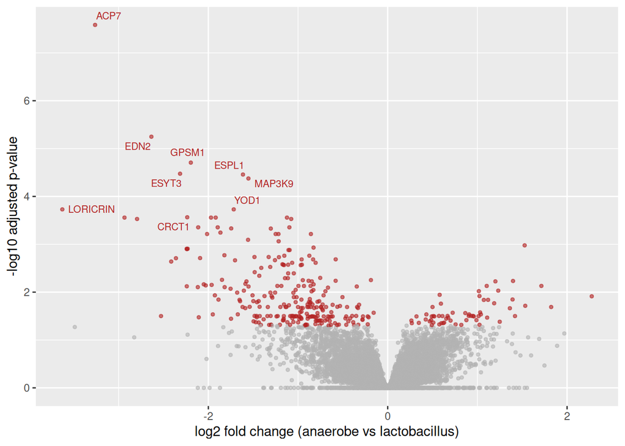

```r
res_c_df |>
  mutate(hit  = padj < 0.05,
         label = if_else(rank(padj) <= 10, symbol, NA_character_)) |>
  ggplot(aes(log2FoldChange, -log10(padj), colour = hit)) +
  geom_point(size = 1, alpha = 0.6, show.legend = FALSE) +
  scale_colour_manual(values = c("grey70", "firebrick")) +
  geom_text_repel(aes(label = label), size = 2.8, max.overlaps = 20,
                  show.legend = FALSE) +
  labs(x = "log2 fold change (anaerobe vs lactobacillus)",
       y = "-log10 adjusted p-value")
```

```r
sig_c |> slice_min(padj, n = 12) |>
  transmute(symbol, log2FC = round(log2FoldChange, 2), FDR = signif(padj, 2)) |>
  knitr::kable(caption = "12 smallest-FDR genes, community type")
```

12 smallest-FDR genes, community type

[output not shown]

> **Sanity check.** Take the top hit’s raw counts, average them within anaerobe and within lactobacillus samples, and divide the two means — converted to log2, that ratio should land near the table’s `log2FC` (DESeq2’s estimate shrinks a little and adjusts for batch, so expect *near*, not *equal*).

# 5. Do the two gene lists overlap? And does the answer survive adjusting for arm?

```r
# The Question 2 list, refit identically to this document for a fair overlap
dds_m <- DESeq(DESeqDataSetFromMatrix(genes_f, md, design = ~ rnaseq_batch + arm_group),
               quiet = TRUE)
res_m <- results(dds_m, contrast = c("arm_group", "ring", "systemic"))
sig_m <- rownames(res_m)[which(res_m$padj < 0.05)]

overlap <- length(intersect(sig_c$ensembl_gene_id, sig_m))

# Sensitivity: does the community signal survive adjusting for the method?
dds_adj <- DESeq(DESeqDataSetFromMatrix(
                   genes_f, md, design = ~ rnaseq_batch + arm_group + community),
                 quiet = TRUE)
res_adj <- results(dds_adj, contrast = c("community", "anaerobe", "lactobacillus"))
sig_adj <- sum(res_adj$padj < 0.05, na.rm = TRUE)
```

```r
knitr::kable(
  tibble(quantity = c(
    "genes at FDR < 0.05, community type",
    "genes at FDR < 0.05, ring vs systemic",
    "genes significant in both lists",
    "community hits surviving adjustment for method",
    "vaginal pH by community (Kruskal–Wallis p)"
  ),
  value = c(nrow(sig_c), length(sig_m), overlap, sig_adj,
            format.pval(kruskal.test(ph ~ community, md)$p.value,
                        digits = 2, eps = 1e-300))),
  caption = "The two groupings compared on the same gene table"
)
```

The two groupings compared on the same gene table

| quantity | value |
| --- | --- |
| genes at FDR < 0.05, community type | 312 |
| genes at FDR < 0.05, ring vs systemic | 165 |
| genes significant in both lists | 27 |
| community hits surviving adjustment for method | 220 |
| vaginal pH by community (Kruskal–Wallis p) | 1.1e-07 |

- **Overlap:** 27 genes are significant in *both* lists — the two questions mostly surface **different genes**, not the same signal measured twice.
- **Sensitivity:** adding the method to the model leaves 220 community hits standing, so the community signal is not a disguised method effect.
- **pH:** it tracks community type far more strongly than it tracks the method (community p = 1.1e-07 vs arm p = 0.02) — consistent with pH being a *microbiome* variable. That reinforces the plan to adjust for community type when reading method effects, and is one more reason the method comparison should be read as suggestive.

# 6. Verdict

- **Overall map:** a near-tie — community type explains 1.4 % of gene-profile variation vs the method’s 1.6 %, both with weak p-values once adjusted for each other (n = 93).
- **Gene by gene:** community type is clearly the stronger signal — **312 genes at FDR < 0.05 (n = 45 vs 48)** vs 165 for ring vs systemic, with little overlap between the lists.
- So the answer to “does community type explain more than the method?” is **yes at the level of individual genes, about a tie for the overall profile** — and since community is balanced across arms, both signals can be reported side by side without one hiding the other.
- Practical rule for the group project: **put community type in the model** when interpreting method effects on genes, and expect the method signal (if real) to be the smaller of the two.